# Data Analytics Project - Sahm Rule

Author

Affiliation

Chester Nguyen

Denison University

# 1 Introduction

## 1.1 About the Sahm Rule

The Sahm rule, developed by economist and Denison alumna [Claudia Sahm](https://en.wikipedia.org/wiki/Claudia_Sahm), is a reliable economic indicator signally the start of a recession in use by the Federal Reserve.

**Sahm Rule**

When the three-month moving average of the national unemployment rate is 0.5 percentage point or more above its low over the prior twelve months, we are in the early months of a recession.

Some useful definitions:

1. A practical definition of recession is two consecutive quarters of decline in a country’s inflation-adjusted gross domestic product (GDP). An economy will stay in recession until it experiences two consecutive quarters of GDP growth, at which point it will move to a state of growth until two consecutive quarters of GDP decline, and so on and so forth.
2. For any given month $k$, the **3-month moving average rate of unemployment** is the average unemployment rate of that month $U_k$ and the two previous months:
   $$\text{MA}(U_k, 3) = \frac{U_k + U_{(k - 1)} + U_{(k - 2)}}{3}$$
   .

## 1.2 About the Project

This project is intended for practicing basic data analytics skills (such as refactoring, merging, data exploration) and exploring new tools, including: the `slider` package, cross-row comparison using `lag()`, factoring using `case_when()`, filling `NA`s using `fill()`, and making time-series plots using the `ggplot` package.

## 1.3 About the Data

We are going to use data from the Federal Reserve Economic Data (FRED). [FRED](https://fred.stlouisfed.org/) “is an online database consisting of hundreds of thousands of economic data time series from scores of national, international, public, and private sources.”

Specifically, our data is going to include quarterly GDP data and monthly unemployment data since January, 1948.

# 2 Doing the Project

## 2.1 Setup

- Create an R-script, RMarkdown, or Quarto Markdown file.

**Tip**

As a best-practice, keep all of your files related to a project in one folder. This should include your script (.r, .qmd, etc.), your dataset, and other files (e.g. this instruction file, your knitted HTML, etc.)

- Import your libraries (and, if using RMarkdown or Quarto Markdown, write your boilerplate).

**Tip**

Using `ggplot2` and `tidyverse` is recommended for this project.

- Download and import the dataset on the national unemployment rate as well as GDP from FRED [here](https://fred.stlouisfed.org/graph/?g=33N6). This will download your data in a .zip file, which you will have to unzip and move to your project folder (or wherever your working directory is).

**Tip**

Use the `read.csv()` function.

**Solution**

```r
unemployment <- read.csv('monthly.csv')
GDP <- read.csv('quarterly.csv')
```

## 2.2 Data Exploration

1. Try to do some exploratory analysis on the datasets What types of variables do you have? What is a single unit of your variable? What can you say about the distribution of your variables? Try using some functions to do your analysis instead of looking directly at the data.

**Tip**

You can use `summary()` and `hist()` to explore your data. Be careful about what their inputs should be.

**Solution**

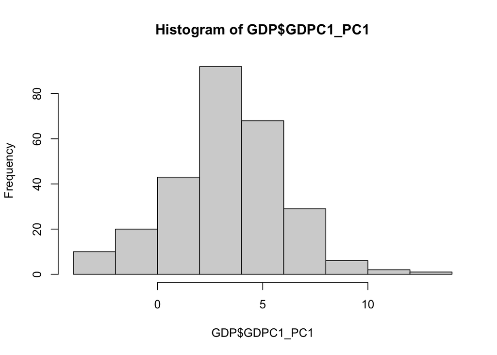

```r
# histograms of GDP and unemployment
hist(GDP$GDPC1_PC1)
```

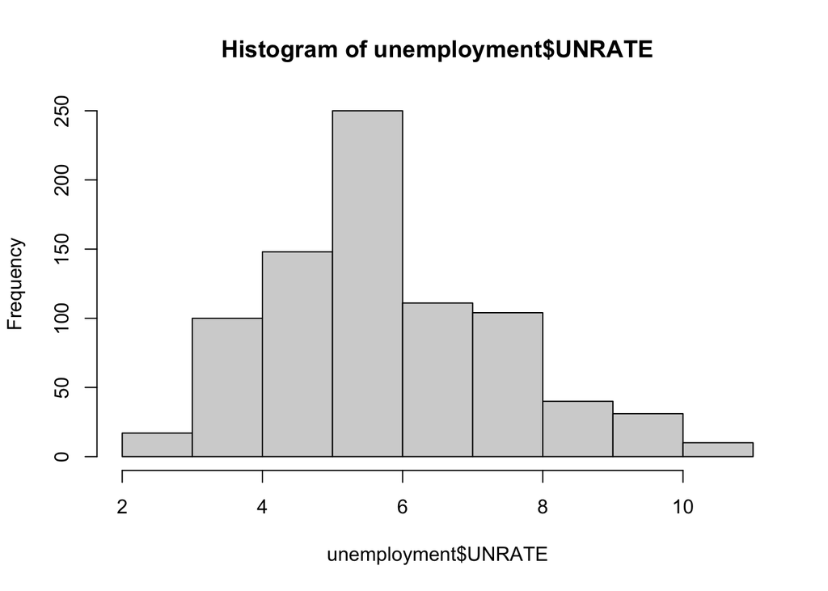

```r
hist(unemployment$UNRATE)
```

```r
# summary of both datasets
summary(GDP)
```

```
 observation_date     GDPC1_PC1
 Length:271         Min.   :-3.979
 Class :character   1st Qu.: 1.840
 Mode  :character   Median : 3.227
                    Mean   : 3.253
                    3rd Qu.: 4.747
                    Max.   :13.372
```

```r
summary(unemployment)
```

```
 observation_date       UNRATE
 Length:811         Min.   : 2.500
 Class :character   1st Qu.: 4.700
 Mode  :character   Median : 5.600
                    Mean   : 5.829
                    3rd Qu.: 6.900
                    Max.   :10.800
```

3. We need to merge our two datasets into one in order to do some analysis. What are two problems in our dataframes to this end?

**Solution**

Our two datasets are of different sizes. The `GDP` dataset has quarterly data but the `unemployment` dataset has monthly data.

Moreover, the “observation-date” in both datasets are character variables and not date variables.

## 2.3 Data Cleaning

### 2.3.1 Refactoring & Merging

Our first step is to refactor our dates.

4. Use the `as.Date()` function to refactor that “observation-date” variable in both dataframes. Recall that you can do this by doing `dataframe$variable <- as.Date(df$variable)`.

**Solution**

```r
GDP$observation_date <- as.Date(GDP$observation_date)
unemployment$observation_date <- as.Date(unemployment$observation_date)
```

Our second step is to merge our datasets into one. When we merge datasets, we identify a column that they both share (i.e. the columns in both datasets that have the same name and the same types of values) and merge by that column. This is an identifying column whose values are unique for each row; think about what column would be.

5. Merge the two dataframes you have into 1. Recall the base-R function for merging: `merge(dataframe_1, dataframe_2, by = "column_name")` and that you can include the specification `all.x = TRUE` to specify that you would like to keep un-merged values from the first dataframe used in the function (this will be useful if one of your dataframes is bigger, e.g. has more granular time data, than the other).

**Solution**

```r
data <- merge(unemployment, GDP, by = "observation_date", all.x = TRUE)
```

We will now create two columns, one for the three-month moving average of the unemployment rate, and one binary column to represent whether we are in a recession by definitional standards.

### 2.3.2 Moving Averages

For our third step, let’s create the moving average first. To do this, you will need to install and load the `slider` package. Then, you will use the `slide_dbl()` function. This function takes in a list of values and uses a rolling window to output another list of values based on the specification (e.g. mean, min, max, etc.):

**`slide_dbl()` Function**

```r
slide_dbl(
  x, # this is our list of values
  min/max/mean, # from the rolling window, do we want to take the minimum, maximum, or average? you can also use other functions
  .before = ,
  .after =,
  ,complete = TRUE/FALSE
)
```

- About the `.before` and `.after` parameters: When you take a rolling average, you have to decide how to align your average. If you want to take a 3-sample after of a value alongside two of the values to its right, the rolling 3-month average for month $k$ will be $\frac{(k + (k + 1) + (k + 2))}{3}$. This is what the `.before` and `.after` parameters are for: they let you choose how many values to the left and to the right of the current value to be used in the computation.
- About the `fill` parameter: After you choose your window, there will be values that are not able to have a rolling average. For example, if you have a window that looks at a value and two other values to its right, then the last entry in your dataset will not have a rolling average because there are no values after it to take the average of. This is what the `.complete` parameter is for: if you set it to `FALSE` (the default value), then it will just take the average without the missing values; if you set it to `TRUE`, then it will leave the value blank.

An example:

```r
slide_dbl(
  c(1, 2, 3, 4, 5),
  min,
  .before = 1,
  .after = 1,
  .complete = TRUE
)
```

```
[1] NA  1  2  3 NA
```

Now let’s actually create the moving average column.

6. Use the `slide_dbl()` function in combination with the `mutate()` function to create a new column to calculate the rolling average for each month. Note that we’ve already been given the alignment for the 3-month rolling average calculation in the introduction.

**Tip**

You can use the `slide_dbl()` function in combination with the `mutate()` function like so:

```r
mutate(
  dataframe,
  rolling_average = slide_dbl()
)
```

**Solution**

```r
data <- data %>% # update the dataset
  mutate( # by creating a new column
    three_month_MA_UNRATE = slide_dbl( # called...
      UNRATE, # by using the unemployment rate,
      mean, # and taking its average
      .before = 2, # over 3 months, aligned right
      .complete = TRUE
    )
  )
```

For our fourth step, let’s create the recession indicator column. Recall the definitions of moving into and out of recessions in the introduction. Creating an recession indicator is tricky because we’re creating a state-process. This means that our indicator will not be contained within each row, but will be a dynamic indicator that compares multiple rows of values.

Our process is as follows:

1. Create a column to indicate whether a recession has started or ended.
2. Resolve some issues that arise with our column.

### 2.3.3 Cross-Row Comparisons & Non-Binary Factoring

For task a, there are two hurdles we need to overcome:

1. Our first hurdle is that we require cross-row comparisons within a single column. To do this, we can use the `lag()` function:

**`lag()` Function**

```r
lag(
  x, # this is the variable that we're using to lag
  n, # this is the number of positions we're lagging by
  default = NA
)
```

- About the `default` parameter: When you lag by $n$, you are looking to the left of a value by $n$ places. However, the first few values you look at won’t have any values when you look to $n$ places to the left of them, so `default` defines what values you should use as a placeholder.

An example:

```r
lag(
  c(1, 2, 3, 4, 5),
  n = 2,
  default = NA
)
```

```
[1] NA NA  1  2  3
```

This makes sense because when we’re looking 2 positions to the left of 3, 4, and 5, we should get 1, 2, and 3 respectively. Moreover, there are no values 2 positions to the left of 1 and 2, so we use `NA` as placeholders.

2. For our second hurdle, we want to distinguish between when a recession starts, when a recession ends, and when there is simply a continuation of the economy being in or out of a recession. When this is the case, we need to be able to generate **cases** in our variable, i.e. that our variable should show `TRUE` when we enter a recession, `FALSE` when we exit, and be `NA` otherwise. To do this, we can use the `case_when()` function:

**`case_when()` Function**

```r
case_when(
  x, # list of values
  condition1 ~ "label1", # what the label for the first condition should be
  condition2 ~ "label2", # what the label for the second condition should be
  ..., # other labels for other conditions
  TRUE ~ "default_label"
)
```

A note on the `TRUE ~ "default_label" specification: If you want the values that don't fall under any condition to remain the same, specify`TRUE ~ column`.

Consider this example:

```r
data.frame(number = 1:5) %>% mutate(
  greater_than_3 = case_when(
    number > 3 ~ TRUE,
    number < 3 ~ FALSE,
    TRUE ~ number
  )
)
```

```
  number greater_than_3
1      1              0
2      2              0
3      3              3
4      4              1
5      5              1
```

This makes sense because 1 and 2 are smaller than 3, while 4 and 5 are greater than 3, and the number 3 is kept the same.

Now let’s actually create the new column by putting it all together.

7. Use the `lag()` and `case_when()` functions in combination with the `mutate()` function to create a new trinary column that indicates whether the current quarter’s GDP is less than the last quarter’s GDP. Note that each quarter is 3 months apart.

**Tip**

You can use the `lag()` and `case_when()` functions in combination with the `mutate()` function like so:

```r
# you can replace ? with ==, !=, >, <, etc., whichever you see fit.

mutate(
  dataframe,
  new_column = case_when(
    (column_of_interest ? lag(column_of_interest)) ~ TRUE,
    (column_of_interest ? lag(column_of_interest)) ~ FALSE,
    TRUE ~ NA
  )
)
```

**Solution**

```r
data <- data %>%
  mutate(
    gdp_decline = GDPC1_PC1 < lag(GDPC1_PC1, 3),
    recession = case_when(
      gdp_decline == TRUE & gdp_decline == lag(gdp_decline, 3) ~ TRUE,
      gdp_decline == FALSE & gdp_decline == lag(gdp_decline, 3) ~ FALSE,
      TRUE ~ NA
    )
  )
```

### 2.3.4 Troubleshooting: Filling and Removal

8. For task b, try to look at the column you just created and compare with the definition of a recession. Do you see any problems?

**Solution**

Our recession definition variable should be a **state-process**, i.e. that it flips between `TRUE` (entering a recession) and `FALSE` (exiting a recession). However, in our column, there are cases of two or more `TRUE`s or `FALSE`s in a row, which makes sense because there could be three or more quarters in a row of GDP decline or growth. Moreover, there is the problem of two quarters of decline, followed by a quarter of growth, followed by another two quarters of decline, which would also “restart” the recession.

Here is the conceptual basis for solving this problem, and the tasks involved:

1. Task 1: Once we enter a recession, it doesn’t matter anymore whether we have another instance of two or more consecutive quarters of GDP decline; this also goes for periods of economic growth. As such, we can temporarily treat the recession column as a “status” column that indicates whether we are *in our out of* a recession, not just when a recession starts or end. To achieve this, we need to fill all `NA`s after `TRUE` with `TRUE` until we hit a `FALSE`, and vice versa; we can use the `fill()` function to do this.

**`fill()` Function**

```r
fill(
  dataframe,
  column,
  .direction =
)
```

About the `.direction` parameter: when you fill missing values in a column, you need to decide how to fill it. Suppose you want a row to **propagate downwards** (this means taking the value in that row and filling every empty row below it with the exact same value), then you specify `.direction = "down"`. Similarly, if you want a row to **propagate upwards**, you specify `.direction = "up`.

9. Use the `fill()` function to fill in the `NA`s in your recession column.

**Tip**

Conceptually, a recession continues after it starts (`TRUE` value appears in the column) and disappears after it ends (`FALSE` value appears in the column). How does this relate to your specification of propagation direction?

**Solution**

```r
data <- fill(data, recession, .direction = "down")
```

2. Task 2: To be able to assess the accuracy of the Sahm rule, we want to revert the recession column back to being a “when does a recession start and end?” column, which means after we hit `FALSE` in the recession column, we need to set every `FALSE` after that to `NA` until we hit a `TRUE`. Same goes for `FALSE` values.
10. Using the same function you used to create the recession column in the first place, can you now modify that same recession column to achieve the result we want in Step 2.

**Tip**

Use the `case_when()` function with the `mutate()` function! Hint: pay attention to the `lag()` step as well as the `NA ~` specification!

**Solution**

```r
data <- data %>%
  mutate(
    recession = case_when(
      recession == lag(recession) ~ NA,
      TRUE ~ recession
    )
  )
```

11. Use the `slide_dbl()` function with the `mutate()` function to create another column that indicates when the Sahm rule is triggered.

**Tip**

Here’s how you use a conditional with the `slide_dbl()` function:

```r
mutate(
  dataframe,
  new_column = referenced_column == slide_dbl(referenced_column)
)
```

**Solution**

```r
data <- data %>% mutate(
  sahm = three_month_MA_UNRATE > slide_dbl(
    three_month_MA_UNRATE,
    min,
    .before = 11
  ) + 0.5
)
```

We will need to modify our Sahm rule variable to only indicate when it triggers for the first time (i.e. we don’t care about consecutive triggers, nor do we care about when it doesn’t trigger).

11. Use a similar technique in Task 2 of your treatment of the recession variable, modify the Sahm rule column to become our desired format.

**Solution**

```r
data <- data %>%
  mutate(
    sahm = case_when(
      sahm == FALSE ~ NA,
      sahm == TRUE & sahm == lag(sahm) ~ NA,
      TRUE ~ sahm
    )
  )
```

That was a lot of data cleaning. In fact, a lot of data analysis is just cleaning data.

## 2.4 Data Analysis

Let’s first motivate our analytical testing of the Sahm rule by visualizing it. Whenever you make a plot with time on the $x$-axis, you are making a **time-series plot**.

12. Using `ggplot()` and `geom_line()`, make a time-series plot of GDP and unemployment over time. Here are a few things to keep in mind:
- In your dataset, GDP is quarterly data and unemployment is monthly data, so you will need to filter your dataset to drop the months that are missing GDP data.
- The scales of GDP and unemployment are different. You can wrap the `scale()` around a variable when you set up the aesthetic layer of your plot.
- You are plotting 2 variables on the $y$-axis against 1 on the $x$-axis. You can do this by only setting the $x$ axis in the `ggplot` and using two `geom_line()` functions with their own aesthetic layer to map GDP and unemployment individually.

**Tip**

Here’s the general structure of what the solution would look like:

```r
filter(data, !is.na(GDP)) %>%
  ggplot(aes(x = date)) +
  geom_line(aes(y = scale(GDP))) +
  geom_line(aes(y = scale(unemploymnet)))
```

**Solution**

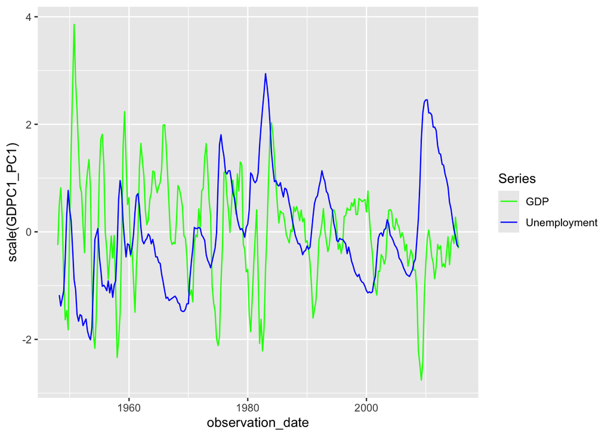

```r
filter(data, !is.na(GDPC1_PC1)) %>%
  ggplot(aes(x = observation_date)) +
  geom_line(aes(y = scale(GDPC1_PC1), color = "GDP")) +
  geom_line(aes(y = scale(three_month_MA_UNRATE), color = "Unemployment")) +
  scale_color_manual(
    name = "Series",
    values = c(
      "GDP" = "green",
      "Unemployment" = "blue"
    )
  )
```

We want to determine how “accurate” the Sahm rule is. We can do this by looking at its **sensitivity** (the ratio of true positives to all positives). Since the Sahm rule claims to predict the *early* stages of a recession and not to *predict* a recession, let’s suppose that it is a true positive when it triggers within 3 months before a recession and within 12 months after it. We can do this using another function from the `slider` package, the `slide_lgl()` function, which works exactly like the `slide_dbl()` function but looks at logical values instead:

**`slide_lgl()` Function**

```r
slide_lgl(
  x, # this is our list of values
  .f, # this is the funtion used to check logic
  .before = ,
  .after =,
  ,complete = TRUE/FALSE
)
```

About the `.f` parameter: you can use a lot of functions to check logic. For checking whether any `TRUE` values exist in the window, set `.f = any` or just write `any`. For checking whether any `FALSE` values exist in the window, set `.f = ~ any(.x == FALSE)` or just write `~ any(x. == FALSE)`. Think about what it means to check whether there are *no* true values or no false values in a window.

13. Using the `slide_lgl()` function along with logic indicators, how would you create a column to check the sensitivity of the Sahm rule?

**Tip**

The Sahm rule is accurate when:

1. A recession occurs close to when the Sahm rule triggers.
2. The Sahm rule triggers close to when a recession occurs.

(Note that the above 2 lines are not necessarily logically equivalent.)

The Sahm rule is inaccurate when:

1. A recession occurs, but the Sahm rule doesn’t trigger.
2. The Sahm rule triggers, but there is no recession.

(Note that the above 2 lines are not necessarily logically equivalent.)

**Solution**

```r
data <- data %>%
  mutate(
    sahm_sensitivity = case_when(
      # these first two rows check whether the Sahm rule triggers close to when a recession occurs
      recession == TRUE & slide_lgl(sahm, any, .before = 2, .after = 11, .complete = FALSE) ~ TRUE,
      recession == TRUE & !slide_lgl(sahm, any, .before = 2, .after = 11, .complete = FALSE) ~ FALSE,
      # these next two rows check whether a recession occurs close to when the Sahm rule triggers
      sahm == TRUE & slide_lgl(recession, any, .before = 11, .after = 2, .complete = FALSE) ~ TRUE,
      sahm == TRUE & !slide_lgl(recession, any, .before = 11, .after = 22, .complete = FALSE) ~ FALSE,
      TRUE ~ NA
    )
  )
```

Finally, we can definitively test the sensitivity of the Sahm rule. We will need to use the `sum()` function to count the total number of nonempty values as well `TRUE` values in our sensitivity column:

**`sum()` Function**

You can use the `sum()` function with a dataframe like so:

```r
sum(!is.na(dataframe$column)) # to count nonempty values in a column
sum(dataframe$column == value, na.rm=TRUE) # to count specific values in a column
```

14. Using `sum()`, test the sensitivity (ratio between when a test is accurate and the sum of the tests’ accurate and inaccurate results) of the Sahm rule. Interpret the result.

**Solution**

```r
sum(data$sahm_sensitivity == TRUE, na.rm=TRUE) / sum(!is.na(data$sahm_sensitivity)) * 100
```

```
[1] 100
```

Woah!!! The Sahm rule is 100% accurate!

# 3 Discussion/Reflection

Here are a few discussion and reflection questions to think about as you wrap up this project:

15. What were your findings? Was there a particular recession or graph that stood out to you?
16. What did you find interesting about the project? What did you find difficult?
17. Why do you think the Sahm rule works so well? Is there a direct link between employment and economic output, or are there other confounding variables?

# 4 Future Work

Here are some ideas for extending on this work:

1. Does the Sahm rule work for other countries? How would you go about collecting data and doing the same analysis?
2. Does the same methodology work for other economic indicators, such as the interest rate, the consumer price index, or the Dow Jones?
3. Is there an “inverse Sahm rule” where if the 3-month moving average of unemployment is some amount lower than the 12-month high, can we accurate predict when a recession ends? Can this “inverse Sahm rule” be incorporated into our analysis?
4. Can you test for **specificity** (the ratio of true negatives and all negatives) for the Sahm rule?

**Solution**

Here’s how you would modify the column for the Sahm rule and the column for sensitivity as well as create the column to check for specificity of the Sahm rule:

```r
data <- data %>%
  mutate(
    sahm = case_when(
      sahm == FALSE & sahm == lag(sahm) ~ NA,
      sahm == TRUE & sahm == lag(sahm) ~ NA,
      TRUE ~ sahm
    ),
    sahm_sensitivity = case_when(
      # these first three rows check whether the Sahm rule triggers close to when a recession occurs
      recession == TRUE & slide_lgl(sahm, any, .before = 2, .after = 11, .complete = FALSE) ~ TRUE,
      recession == TRUE & !slide_lgl(sahm, any, .before = 2, .after = 11, .complete = FALSE) ~ FALSE,
      recession == TRUE & slide_lgl(sahm, ~ any(.x == FALSE), .before = 2, .after = 11, .complete = FALSE) ~ FALSE,
      # these next three rows check whether a recession occurs close to when the Sahm rule triggers
      sahm == TRUE & slide_lgl(recession, any, .before = 11, .after = 2, .complete = FALSE) ~ TRUE,
      sahm == TRUE & !slide_lgl(recession, any, .before = 11, .after = 2, .complete = FALSE) ~ FALSE,
      sahm == TRUE & slide_lgl(recession, ~ any(.x == FALSE), .before = 11, .after = 2, .complete = FALSE) ~ FALSE,
      TRUE ~ NA
    ),
    sahm_specificity = case_when(
      recession == FALSE & slide_lgl(sahm, ~ any(.x == FALSE), .before = 2, .after = 11, .complete = FALSE) ~ TRUE,
      recession == FALSE & !slide_lgl(sahm, ~ any(.x == FALSE), .before = 2, .after = 11, .complete = FALSE) ~ FALSE,
      recession == FALSE & !slide_lgl(sahm, any, .before = 2, .after = 11, .complete = FALSE) ~ FALSE,
      sahm == FALSE & slide_lgl(recession, ~ any(.x == FALSE), .before = 11, .after = 2, .complete = FALSE) ~ TRUE,
      sahm == FALSE & !slide_lgl(recession, ~ any(.x == FALSE), .before = 11, .after = 2, .complete = FALSE) ~ FALSE,
      sahm == FALSE & !slide_lgl(recession, any, .before = 11, .after = 2, .complete = FALSE) ~ FALSE,
      TRUE ~ NA
    )
  )

sum(data$sahm_sensitivity == TRUE, na.rm=TRUE) / sum(!is.na(data$sahm_sensitivity)) * 100
sum(data$sahm_specificity == TRUE, na.rm=TRUE) / sum(!is.na(data$sahm_specificity)) * 100
```

This is a lot of code and a lot to understand conceptually! If you are reading this at all, take as much time as you need to parse through this.

5. In our analysis, we restricted the definition of a recession as moving into a recession; we also restricted our Sahm indicator to flash just once. If we removed these restrictions (i.e. add dimensionality to a recession either by measuring its duration by determining when recessions end or by attributing meaning to the ratio of positive v. negative GDP change in a recession; adding dimensionality to the Sahm rule by measuring how many times it flashes), are there other interesting methods of analysis we can do?